# Exploración de datos y elección de pruebas o modelos

Domingo Martínez

2024-05-17

# 1 Introducción

En esta sesión vamos a trabajar en los siguientes objetivos de aprendizaje:

- Explorar la consistencia y calidad de nuestros datos.
- Identificar la escala de nuestras variables de interés.
- Identificar en qué casos podríamos:
  - Hacer una descripción.
  - Hacer algúna comparación.
  - Modelar relaciones “causales”.

En este script vamos a trabajar con la misma base de datos utilizada en el artículo: *“Machine learning in medicine: Performance calculation of dementia prediction by support vector machines (SVM)”*, publicado en 2019 por Gopi Battineni, Nalini Chintalapudi, y Francesco Amenta. Quienes usan la base de datos pública llamada OASIS-2.

El artículo y repositorios se pueden consultar en:

- https://www.oasis-brains.org/
- https://direct.mit.edu/jocn/article/22/12/2677/4983/Open-Access-Series-of-Imaging-Studies-Longitudinal
- https://www.sciencedirect.com/science/article/pii/S2352914819300917?via%3Dihub
- https://doi.org/10.1016/j.imu.2019.100200
- https://data.mendeley.com/datasets/tsy6rbc5d4/1
- https://www.kaggle.com/datasets/shashwatwork/dementia-prediction-dataset?select=dementia_dataset.csv

La base de datos en cuestión, tiene información clínica, socio-demográfica, datos de rendimiento cognitivo y datos longitudinales de imagen cerebral por resonancia magnética de 150 participantes diestros; con, o sin demencia, con edades entre 60 y 96 años. Las variables contenidas en la base de datos (OASIS-2) son:

- Subject ID (Número de identificación del sujeto)
- MRI ID (Número de identificación temporal de la resonancia, recordemos que se trata de un estudio longitudinal con hasta 3 resonancias separadas por un año)
- Group {Indica si pertenece al grupo con demencia, sin demencia o convertido, estos últimos se habían tratado inicialmente com con demencia, luego se trataron como sin demencia}
- Visit (Indica el número de vistia para adquirir las imágenes de resonancia magnética)
- MR delay (Días transcurridos entre cada resonancia)
- Sex (Indica el sexo del participante, M = masculino, F = femenino)
- Age (Edad del participante en años cumplidos)
- Social Economic Status (SES, nivel socio económico con 5 niveles, el más alto es 5)
- Education level (EDUC, nivel de educación en años cursados en el sistema escolar)
- MMSE (mini-mental state examination parameters, indica el resultado de la prueba minimental, que sirve para medir el deterioro cognitvo)
- Clinical Dementia Ratio (CDR) Con base en una entrevista, se evalúan áreas cognitivas y funcionales del paciente, los códigos son:
  - 0 = sin demencia.
  - 0.5 = demencia muy leve.
  - 1 = demencia leve.
  - 2 = demencia moderada.
  - 3 = demencia severa.
- Estimated Total Intracranial Volume (e-TIV) Volumen intercranial total estimado.
- Normalized Whole Brain Volume (n-WBV) Volumen normalizado del cerebro.
- Atlas Scaling Factor, convierte “las coordenadas” del cerebro a las “coordenadas” del atlas cerebral que se usará.

## 1.1 PASO 1: Lectura de la base de datos

NOTA: para abrir un chunk de R el atajo es: ctrl + alt + i

```r
bd.demencia <- read.csv("oasis_longitudinal_demographics.csv")
```

Para eachar un ojo a mi base de datos puedo usar el comando View()

```r
View(bd.demencia)
```

❓

RETO: ¿Cuántas variables y cuantos registro tenemos?

RETO: ¿Cuántos NAs tengo?

## 1.2 PASO 2: Visualización de NAs

Podemos usar el paquete visdat para echar un vistazo y saber qué tantos valores perdidos tengo.

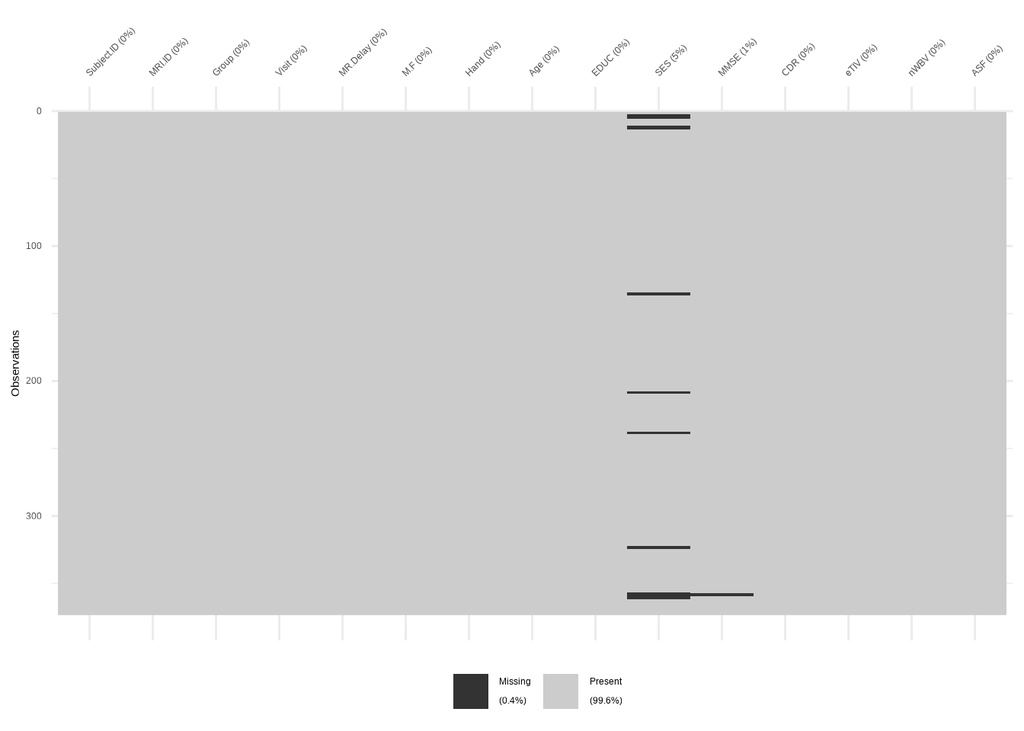

```r
library(visdat)
visdat::vis_miss(bd.demencia)
```

RETO: ¿Cuál es la variable que más valores perdidos tiene?

RETO: ¿Qué debería hacer con los valores perdidos o NAs?

# 2 Tipos de datos

En nuestro ejemplo tenemos una base de datos tabular, o conjunto de datos tabulares. Aquí la información se estructura de la siguiente manera, en cada renglón tenemos un caso u observación, y en cada columna registramos los datos de una, y solo una variable.

En términos generales, la escala de medición en la cual están registrados los datos de cada variable, para cada sujeto, nos indican el tipo de valor o dato que tengo registrado.

## 2.1 Escalas de medición

Las escalas de medición nos permiten organizar los datos en orden jerárquico, a continuación vamos a describirlas desde la más “simple” a la más “completa”.

Fuentes:

- Siegel, S., & Castellan, J. (1998). Nonparametric statistics for the behavioral sciences- (2nd ed.). Mcgraw-Hill Book Company.
- https://en.wikipedia.org/wiki/Level_of_measurement

### 2.1.1 Escala nominal o categórica.

Corresponde al nivel de medición “más débil”, aquí usamos símbolos para identificar los grupos a los que pertencen nuestras observaciones. Por ejemplo, registremos el color favorito de quienes asisten a este taller.

```r
data.frame(Sujetos_ID=c(1:5),Color_favorito = c("azul",
                                              "verde",
                                              "azul",
                                              "rojo",
                                              "rojo"))
```

| Sujetos_ID | Color_favorito |
| --- | --- |
| 1 | azul |
| 2 | verde |
| 3 | azul |
| 4 | rojo |
| 5 | rojo |

En esta escala solo podemos aplicar los operadores matemáticos $=$ y $\neq$; además podemos agrupar y calcular la moda.

### 2.1.2 Escala ordinal.

Si en una escala categórica, resulta que, podemos organizar las categorías de acuerdo a una jerarquía dictada por el operador $>$, entonces tenemos una escala ordinal. Un ejemplo muy común es la escala likert.

```r
data.frame(Sujetos_ID=c(1:5),
           Gusto_por_chocolate = c("1", "3",  "3", "2", "1"))
```

| Sujetos_ID | Gusto_por_chocolate |
| --- | --- |
| 1 | 1 |
| 2 | 3 |
| 3 | 3 |
| 4 | 2 |
| 5 | 1 |

En esta escala podemos aplicar los operadores $>$ y $<$ para ordenar las respuestas. También podemos calcular la mediana.

😱

**IMPORANTE:** ¿Podemos estar segurxs que, la distancia entre “me gusta poco” a “me gusta mucho”, es igual entre todxs nuetrxs sujetos?

RETO: responde a la pregunta anterior…

### 2.1.3 Escala de intervalo.

Si, en una escala ordinal, resulta que, podemos conocer el intervalo (i.e., distancia) entre categorías. En este caso tendremos una escala de intervalo. Importante: en esta escala, el punto cero y la unidad de medidas son arbitrarios. El ejemplo más común que tenemos es la temperatura medida en grados fahrenheit o en grados celcius; el cero es arbitrario y tenemos dos unidades de medida. No obstante, ambas escalas tienen la misma cantidad y la misma clase de información.

NOTA: **la razón entre dos intervalos** es independiente de la unidad de medida y del punto cero, pero, el cero y la unidad de medida son arbitrarios. Entonces, unidades diferentes arrojarán razones diferentes.

A diferencia de las escalas anteriores, en la escala de intervalo, sí podemos aplicar los operadores matemáticos $+$ y $-$. Y ya podemos calcular la media aritmética.

```r
data.frame(Sujetos_ID=c(1:4),
           Temperatura_corporal_celciuls = c(36.5, 37.2, 38.0, 37.1),
           Temperatura_corporal_fahrenheit = c(97.7, 98.96, 100.4, 98.78)
           )
```

| Sujetos_ID | Temperatura_corporal_celciuls | Temperatura_corporal_fahrenheit |
| --- | --- | --- |
| 1 | 36.5 | 97.70 |
| 2 | 37.2 | 98.96 |
| 3 | 38.0 | 100.40 |
| 4 | 37.1 | 98.78 |

### 2.1.4 Escala de razón.

Si una escala de intervalo tiene un punto cero absoluto o verdadero, entonces tendremos una escala de razón, porque, **la razón (ratio) entre dos puntos**, es independiente de la unidad de medida.

Un buen ejemplo es la medición de la masa, sin importar si medimos en kilogramos o en libras, existe un zero verdadero o absoluto. Y la razón entre dos pesos es la misma, sin importar que lo midamos en kilogramos o en libras.

En otras palabras, las razones (ratios) entre dos valores serán iguales pese que se hayan medido en unidades diferentes. A datos medidos en esta escala le podemos aplicar la media arítmética y también la geométrica.

```r
data.frame(Sujetos_ID=c(1:4),
           Peso_kgs = c(62.5, 78.4, 60.1, 82.4),
           Peso_lbs = c(137.79, 172.84, 132.5, 181.66)
           )
```

| Sujetos_ID | Peso_kgs | Peso_lbs |
| --- | --- | --- |
| 1 | 62.5 | 137.79 |
| 2 | 78.4 | 172.84 |
| 3 | 60.1 | 132.50 |
| 4 | 82.4 | 181.66 |

*En la “medida” de los posible, siempre nos gustaría tener una escala de razón.*

RETO: ¿Estas son las únicas escalas de medición?

## 2.2 Tipo o formato de nuestros datos

Fuente: https://bookdown.org/chescosalgado/intro_r/tipos-y-estructuras-de-datos-en-r.html

Normalmente tenemos los siguientes tipos de datos

| Tipo de dato | Descripción |
| --- | --- |
| Numeric | Números decimales |
| Integer | Números enteros |
| Character | Cadenas de texto |
| Complex | Números complejos |
| Logical | Valor verdadero o falso |
| Factor | Agrupación por categorías y niveles |

**Y, la pregunta del millón es:**

*¿Qué formato o tipo de datos deben tener cada una de las escalas de medición descritas anteriormente*

**ACTIVIDAD:** Completa el tipo de datos

- Escala nominal -> datos tipo…
- Escala ordinal -> datos tipo…
- Escala de intervalo -> datos tipo…
- Escala de razón -> datos tipo…

RETO: ¿Cómo podemos diferenciar el tipo de datos de una variable en una escala ordinal en comparación con una variable de razón que solamente tenga números enteros?

## 2.3 Exploración del tipo de datos

Ahora, con ayuda de la función str() revisaremos qué formato o tipo de datos tiene cada una de nuestras variables.

```r
str(bd.demencia)
```

```
## 'data.frame':    373 obs. of  15 variables:
##  $ Subject.ID: chr  "OAS2_0001" "OAS2_0001" "OAS2_0002" "OAS2_0002" ...
##  $ MRI.ID    : chr  "OAS2_0001_MR1" "OAS2_0001_MR2" "OAS2_0002_MR1" "OAS2_0002_MR2" ...
##  $ Group     : chr  "Nondemented" "Nondemented" "Demented" "Demented" ...
##  $ Visit     : int  1 2 1 2 3 1 2 1 2 3 ...
##  $ MR.Delay  : int  0 457 0 560 1895 0 538 0 1010 1603 ...
##  $ M.F       : chr  "M" "M" "M" "M" ...
##  $ Hand      : chr  "R" "R" "R" "R" ...
##  $ Age       : int  87 88 75 76 80 88 90 80 83 85 ...
##  $ EDUC      : int  14 14 12 12 12 18 18 12 12 12 ...
##  $ SES       : int  2 2 NA NA NA 3 3 4 4 4 ...
##  $ MMSE      : int  27 30 23 28 22 28 27 28 29 30 ...
##  $ CDR       : num  0 0 0.5 0.5 0.5 0 0 0 0.5 0 ...
##  $ eTIV      : num  1987 2004 1678 1738 1698 ...
##  $ nWBV      : num  0.696 0.681 0.736 0.713 0.701 ...
##  $ ASF       : num  0.883 0.876 1.046 1.01 1.034 ...
```

**ACTIVIDAD:** Revisa que, cada variable esté declarada en el formato o tipo de datos adecuado.

RETO: Si el tipo de los datos no es el adecuado para algunas variables, entonces formatea al tipo correcto.

TIP: Consulta la descripción de cada variable en la **Introducción**.

## 2.4 Formateo del tipo de datos

TIP: Recuerda verificar que tus variables tienen declarado el tipo de datos correcto.

# 3 Exploración visual de mi base de datos

A continuación, hagamos una exploración visual inicial a nuestra base de datos. Este paso es indispensable para identificar errores o corroborar que nuestra base de datos corresponde a lo esperado.

```r
library(GGally)
```

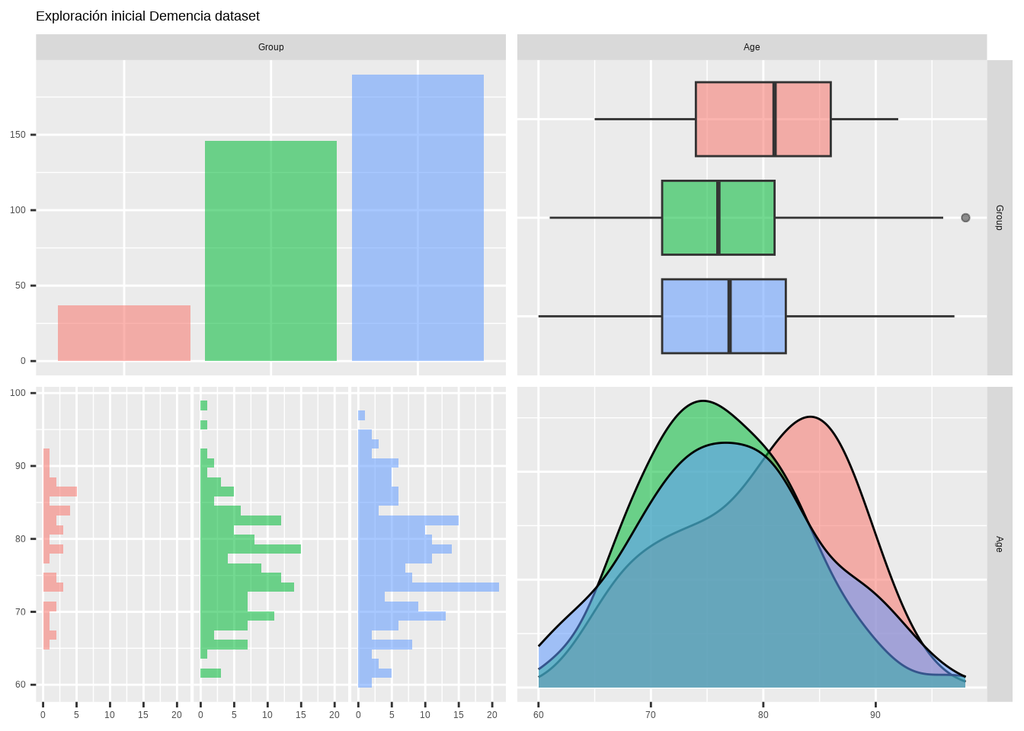

```r
ggpairs(data = bd.demencia[,c(3,8)],
        aes(color=Group,
            alpha=0.6),
        title = "Exploración inicial Demencia dataset")
```

```r
ggsave("Exploracion_inicial_demencia.png",
       plot = last_plot(),
       device = png,
       width = 30,
       height = 20,
       units = c("cm"),
       dpi = 300)
```

# 4 Aplicando estadística para responder preguntas